# Lab 1 DS@USF 1/23/20

# Using R

We’re going to approach analyzing data from a development perspective.

In a basic workflow, basic steps are:

- Collect data (e.g. Iris dataset, here the data is already extracted for us).  
  *Also the data has already been largely preprocessed for us, this is often not the case with real data!*
- Preprocess as needed (how can we represent the data in a way that makes sense).
- Let your analysis be lead by specific questions.

We’ll be leveraging the power of R as a programming language to demo how an analyst can use development methods to drill into specific questions of ttheir analysis.

# What about IRIS?

But first, we need to think about the data we’re looking at - What does the iris dataset represent? - As researchers, waht questiones should we specifically asking about how the data is transcribed? - What actionable results do we intend to produce with the data for the domain?

```r
head(iris, 4)
```

```
##   Sepal.Length Sepal.Width Petal.Length Petal.Width Species
## 1          5.1         3.5          1.4         0.2  setosa
## 2          4.9         3.0          1.4         0.2  setosa
## 3          4.7         3.2          1.3         0.2  setosa
## 4          4.6         3.1          1.5         0.2  setosa
```

## Installing Packages

The general form is to use the intall.packages("") function in R

```r
# We need these packages today
install.packages("dplyr")
install.packages("ggpubr")
```

# Loading packages

- Libraries represent modular units of functions we already have been developed for us to use (R is open source)
- We’ll be using them to help us munge data through our analysis
- The development side (reproduce and R objects)

```r
library(dplyr) #  for helping query our data
library(ggpubr) #  for visualizations
```

# Representing Data

- The dataframe is one of the essential components of the R language
- Functions are built on top of the idea that an person developing in R will be working with a dataframe

```r
# iris already exists in our environment, we just need to assign it to a variable for us to work with it
my_iris_dataframe <- data.frame(iris) #  x holds iris
```

## Get To Know Your Data

- The levels function allows us to examine and audit all the possible unique values of a vector (column) in R
- The $ operator allows us to access specific elements of *any* object in R
- What are factors?

```r
levels(my_iris_dataframe$Species) # look of values of vector here
```

```
## [1] "setosa"     "versicolor" "virginica"
```

# Get To Know Your Data

- str is another function developed witht he dataframe in mind, allowing us to audit the str of our dataframe
1. Looking at the data structures of the columns
2. Help us identify unique factors

```r
head(my_iris_dataframe, 2)
```

```
##   Sepal.Length Sepal.Width Petal.Length Petal.Width Species
## 1          5.1         3.5          1.4         0.2  setosa
## 2          4.9         3.0          1.4         0.2  setosa
```

```r
str(my_iris_dataframe)
```

```
## 'data.frame':    150 obs. of  5 variables:
##  $ Sepal.Length: num  5.1 4.9 4.7 4.6 5 5.4 4.6 5 4.4 4.9 ...
##  $ Sepal.Width : num  3.5 3 3.2 3.1 3.6 3.9 3.4 3.4 2.9 3.1 ...
##  $ Petal.Length: num  1.4 1.4 1.3 1.5 1.4 1.7 1.4 1.5 1.4 1.5 ...
##  $ Petal.Width : num  0.2 0.2 0.2 0.2 0.2 0.4 0.3 0.2 0.2 0.1 ...
##  $ Species     : Factor w/ 3 levels "setosa","versicolor",..: 1 1 1 1 1 1 1 1 1 1 ...
```

# Useful Functions in R

- R is developed by statisticians, so we can get some measures of center from the dataframe by just running summary on our dataframe
- Notice how we can get the amount of observations and variables

```r
summary(my_iris_dataframe)
```

```
##   Sepal.Length    Sepal.Width     Petal.Length    Petal.Width
##  Min.   :4.300   Min.   :2.000   Min.   :1.000   Min.   :0.100
##  1st Qu.:5.100   1st Qu.:2.800   1st Qu.:1.600   1st Qu.:0.300
##  Median :5.800   Median :3.000   Median :4.350   Median :1.300
##  Mean   :5.843   Mean   :3.057   Mean   :3.758   Mean   :1.199
##  3rd Qu.:6.400   3rd Qu.:3.300   3rd Qu.:5.100   3rd Qu.:1.800
##  Max.   :7.900   Max.   :4.400   Max.   :6.900   Max.   :2.500
##        Species
##  setosa    :50
##  versicolor:50
##  virginica :50
##
##
##
```

```r
# Doesn't have to be in the presentation, but specific interpretations would be nice here
```

# “Writing Queries” Against a Dataframe

- In SQL we have phrases for selecting columns and manipulating . Dplyr has similar verbs: gather, select, arrange, mutate, filter among others
- Within the R environment, we can combine these with other functions (because everything in R is a function) to answer specific questions about our data
- What are we doing with the filter verb here?

```r
#  Notice how simialry to SQL, we can use a verb against a 'table' and filter it as we like
filter(my_iris_dataframe,Species=="virginica")
```

[output not shown]

# “Writing Queries” Against a Dataframe

```r
#  unlike in SQL, we can treat the output of this code like an object
my_flower_table <- filter(my_iris_dataframe,Species=="virginica")

count(my_flower_table) # then we can use another function to see how many flowers are 'virginica'
```

```
## # A tibble: 1 x 1
##       n
##   <int>
## 1    50
```

# “Writing Queries” Against a Dataframe

- In practice, we can jsut use the verbs together and structure our code more like a query
- Because R is a functional programming language, we can use something like the pipe ‘%>%’ to stick one object of R to another object

```r
filter(my_iris_dataframe,Species=="virginica") %>%
  count()
```

```
## # A tibble: 1 x 1
##       n
##   <int>
## 1    50
```

# More Examples

```r
select(my_iris_dataframe, Sepal.Length, Sepal.Width, Species) %>%
  filter(Species=="virginica" & Sepal.Length<6 & Sepal.Width<=2.7)
```

```
##   Sepal.Length Sepal.Width   Species
## 1          5.8         2.7 virginica
## 2          4.9         2.5 virginica
## 3          5.7         2.5 virginica
## 4          5.8         2.7 virginica
```

# More Examples

- The arrange verb is similar to ‘order by’ in SQL, allowing us to order by multiple columns

```r
head(arrange(my_iris_dataframe, Sepal.Length, desc(Sepal.Width)), 8)
```

```
##   Sepal.Length Sepal.Width Petal.Length Petal.Width Species
## 1          4.3         3.0          1.1         0.1  setosa
## 2          4.4         3.2          1.3         0.2  setosa
## 3          4.4         3.0          1.3         0.2  setosa
## 4          4.4         2.9          1.4         0.2  setosa
## 5          4.5         2.3          1.3         0.3  setosa
## 6          4.6         3.6          1.0         0.2  setosa
## 7          4.6         3.4          1.4         0.3  setosa
## 8          4.6         3.2          1.4         0.2  setosa
```

```r
# What does this specifically help us achieve ?
```

# A more complex query

- From an analysis perspective, we can use a package like dplyr to produce tables which help us drive a point home about aggregations or patterns we’re detecting in our dataset
- What are we trying to accomplish here (what’s our expected table)?
- The summarize function allows us to combine several forms of aggregations within one larger query i.e the mean, the median

```r
my_iris_dataframe %>%
  group_by(Species) %>%
  summarise (
  mean_petal_length =  mean(Petal.Length),
  mean_sepal_length = mean(Sepal.Length),
  median_sepal_width = median(Sepal.Width),
  median_pedal_width = median(Petal.Width)
)
```

# A more complex query

- We also need to keep in mind that often, we will need to report our findings to a less technical audience

| Species | mean_petal_length | mean_sepal_length | median_sepal_width | median_pedal_width |
| --- | --- | --- | --- | --- |
| setosa | 1.462 | 5.006 | 3.4 | 0.2 |
| versicolor | 4.260 | 5.936 | 2.8 | 1.3 |
| virginica | 5.552 | 6.588 | 3.0 | 2.0 |

# Visualization Tools

What questions may we be trying to answer as researchers for iris?

```r
library(ggpubr)
```

# Visualization Tools

- Are there signficant differences between the flowers in terms of their different measurements, does the species matter ?
- Are the features (columns) related to each other in a significant way?
- Can we predict the value of say, the petal length, based on the other features in the dataset?
- Can we develop a sort of taxonomy for these flowers based on historical data?

```r
library(ggpubr)
# #   ggpubr is a package built on TOP of ggplot
```

- Graphing with a programming language introduces the concept of the “grammar of data”
- ggpubr is a wrapper built on top of ggplot. It is the parallel to ‘seaborn’ in Python for statistical plots
- Practically, it helps us determine **whether a relationship exists between the features before implementing a model**

# Are there signficant differences between the flowers in terms of their different measurements, does the species matter ?

- We explore to see whether a relationship exists before we implement a model
- This way, we attempt to gaurd against the random predictions of the model and we can justify the way we fit the model in practice and the predictions it makes
- We’ll use the box plot to see if we can detect significant differences between the levels in our iris data

```r
plot_species_length <- ggviolin(my_iris_dataframe,
         x = "Species",
         y = "Sepal.Length",
         fill = "Species",
         palette = c("#00AFBB", "#E7B800", "#FC4E07"),
         add = "boxplot", add.params = list(fill='white')
         )
```

# Are there signficant differences between the flowers in terms of their different measurements, does the species matter ?

- What can this plot tell us?

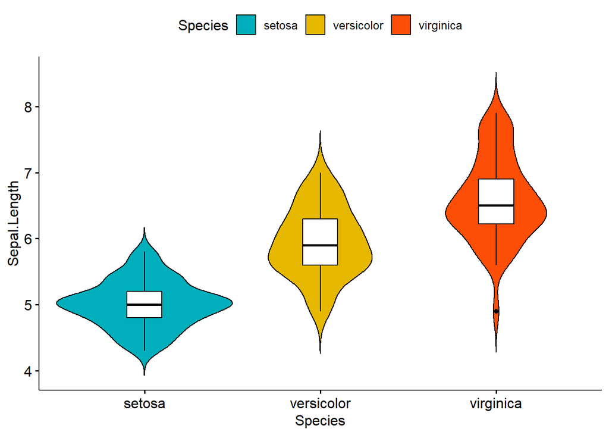

# Sprinkle Statistics - Does the species matter ?

- Remember, everything in R is an object!
- We compare setosa against versicolor and virginica with a comparison of means stat test

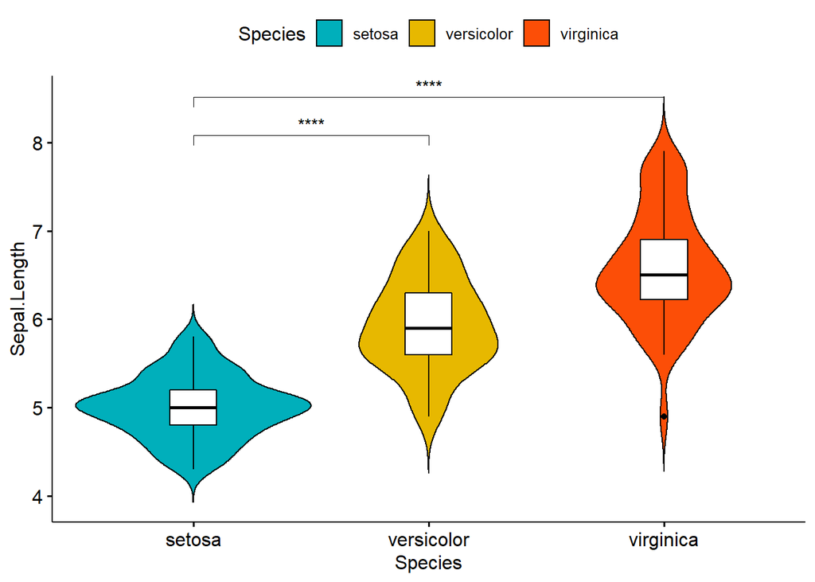

```r
compare_species <- list( c("setosa", "versicolor"), c("setosa", "virginica"))
#  we use the list data structure to tell R how to compare the means of the species
plot_species_length + stat_compare_means(comparisons = compare_species, label = "p.signif")
```

```r
# + stat_compare_means(label.y = 50)
```

# Are the features (columns) related to each other in a significant way?

- Let’s focus on the graph and cool it on the code for now (there are mutliple ways to get scatterplot matrices)
- Scatterplot matrixes can be used to tease out relationships between numerical values

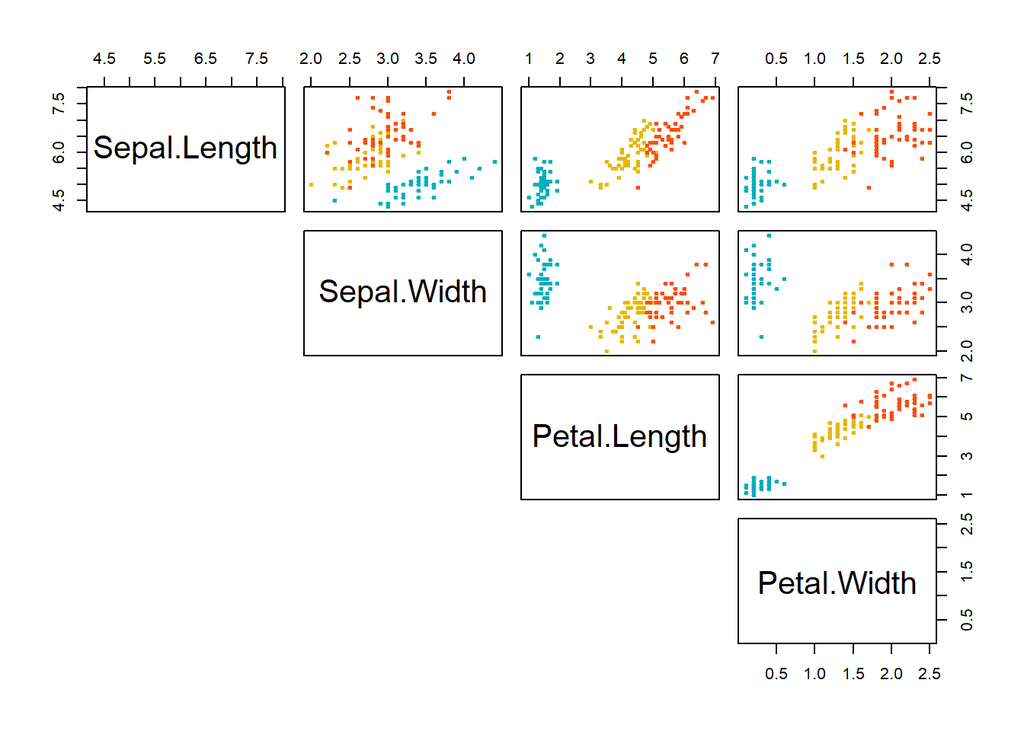

# Wrapping Up

- We can see how the role of the data scientists encompasses both the technical aspects of working with structures of data **and** interpreting our findings
- We draw from the world of software development to do this, recognizing the advantages of R as a functional programming language for us to flexibily manipulate our dataframe
- We also recognize the importance of being able to reproduce our work with readable code, where we can understand and justify our analysis if we give it to someone else
- Visualization helps us explore and gain a better sense of our data, allowing us to use a unified grammar of graphics to talk about ‘seeing’ data in a unified way
- Munging and exploring our data with tables and plots helps us understand whether a relationship exists **before** we model our data (if necessary). Data exploration is embedded in **every part** of the data science lifecycle

# Wrapping Up

- Upload your code to the github assignment on Canvas! Don’t worry if it doesn’t run (but kudos if it does!)
- Next time, we will use our toolsets to help us implement a regression model, and understand how regression works, to prep us for our first competition!
- Choose your teams by next week **No teams with the same majors allowed :)**
- Grad student panel
- Move meeting time to later?